# DK Forest LiDAR - Gradient Boosting Model Performance

Jakob Assmann

09/08/2022

## Models trained using BIOWIDE stratification

For these models the training data was split according to the BIOWIDE stratification.

### Variable importance

Variable importance for this boosted regression tree model.

```
##                                                             var  rel.inf
## dtm_10m                                                 dtm_10m 9.436428
## Sand_utm32_10m                                   Sand_utm32_10m 9.410692
## treetype_bjer_dec                             treetype_bjer_dec 7.586392
## Clay_utm32_10m                                   Clay_utm32_10m 6.717277
## Soc_utm32_10m                                     Soc_utm32_10m 6.288340
## ns_groundwater_summer_utm32_10m ns_groundwater_summer_utm32_10m 5.873385
## dtm_10m_sd_110m                                 dtm_10m_sd_110m 5.429778
## amplitude_sd                                       amplitude_sd 5.258751
## canopy_height                                     canopy_height 5.022070
## vegetation_density                           vegetation_density 4.780821
## canopy_height_sd_110m                     canopy_height_sd_110m 4.767433
## ns_groundwater_summer_sd_110m     ns_groundwater_summer_sd_110m 4.674164
## solar_radiation                                 solar_radiation 4.625719
## vegetation_density_sd_110m           vegetation_density_sd_110m 4.329235
## normalized_z_sd                                 normalized_z_sd 4.155538
## foliage_height_diversity               foliage_height_diversity 3.908227
## amplitude_mean                                   amplitude_mean 3.760337
## slope                                                     slope 2.515989
## openness_difference                         openness_difference 1.459423
```

### Performance in BIOWIDE regions:

Performance map based on the independent validation data:

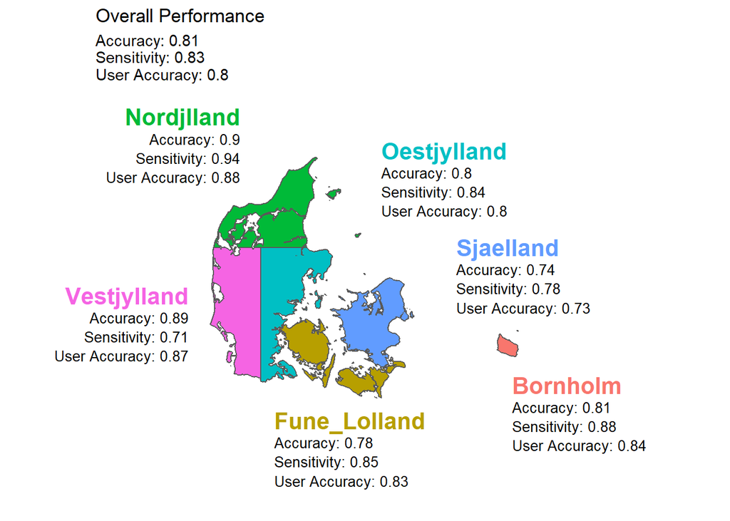

Performance table based on the independent validation data:

| Measure | Overall | Bornholm | Fune_Lolland | Nordjlland | Oestjylland | Sjaelland | Vestjylland |
| --- | --- | --- | --- | --- | --- | --- | --- |
| Accuracy | 0.81 | 0.81 | 0.78 | 0.90 | 0.80 | 0.74 | 0.89 |
| Error | 0.19 | 0.19 | 0.22 | 0.10 | 0.20 | 0.26 | 0.11 |
| Sensitivity (True Positive Rate) | 0.83 | 0.88 | 0.85 | 0.94 | 0.84 | 0.78 | 0.71 |
| Specificity (True Negative Rate) | 0.78 | 0.70 | 0.63 | 0.86 | 0.76 | 0.70 | 0.96 |
| Fall-out (False Positive Rate) | 0.22 | 0.30 | 0.37 | 0.14 | 0.24 | 0.30 | 0.04 |
| Positive predictive value (User Accuracy) | 0.80 | 0.84 | 0.83 | 0.88 | 0.80 | 0.73 | 0.87 |

Performance table based on the dependent training data:

| Measure | Overall | Bornholm | Fune_Lolland | Nordjlland | Oestjylland | Sjaelland | Vestjylland |
| --- | --- | --- | --- | --- | --- | --- | --- |
| Accuracy | 0.99 | 1.00 | 0.99 | 1.00 | 1.00 | 0.99 | 0.99 |
| Error | 0.01 | 0.00 | 0.01 | 0.00 | 0.00 | 0.01 | 0.01 |
| Sensitivity (True Positive Rate) | 0.99 | 1.00 | 1.00 | 0.99 | 0.99 | 0.99 | 0.97 |
| Specificity (True Negative Rate) | 0.99 | 0.99 | 0.99 | 1.00 | 1.00 | 0.99 | 1.00 |
| Fall-out (False Positive Rate) | 0.01 | 0.01 | 0.01 | 0.00 | 0.00 | 0.01 | 0.00 |
| Positive predictive value (User Accuracy) | 0.99 | 1.00 | 1.00 | 1.00 | 1.00 | 0.99 | 1.00 |

### Perfromance in Derek’s regions:

Performance map based on the independent validation data:

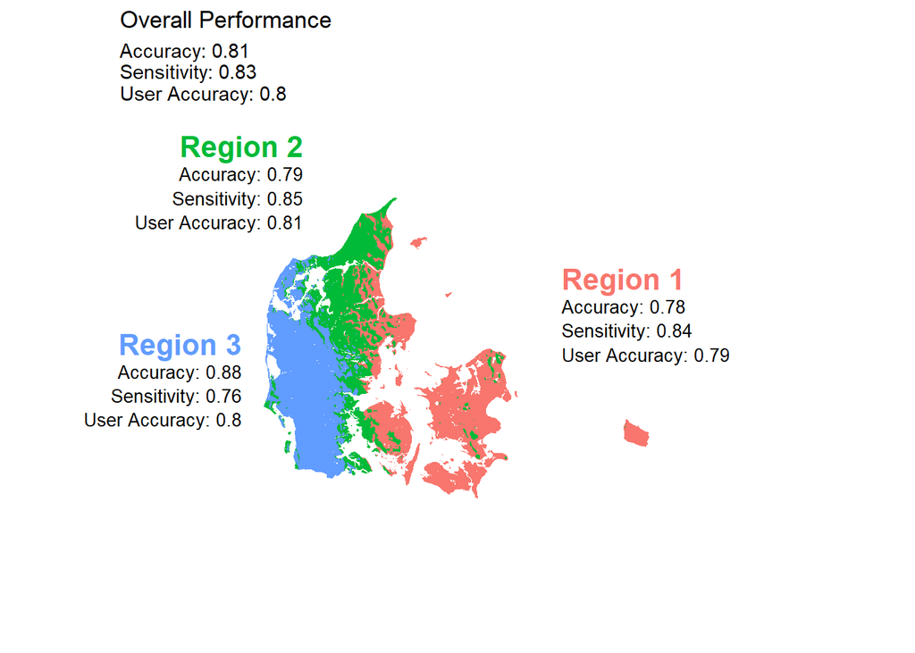

Performance table based on the independent validation data:

| Measure | Overall | Region 1 | Region 2 | Region 3 |
| --- | --- | --- | --- | --- |
| Accuracy | 0.81 | 0.78 | 0.79 | 0.88 |
| Error | 0.19 | 0.22 | 0.21 | 0.12 |
| Sensitivity (True Positive Rate) | 0.83 | 0.84 | 0.85 | 0.76 |
| Specificity (True Negative Rate) | 0.78 | 0.69 | 0.73 | 0.92 |
| Fall-out (False Positive Rate) | 0.22 | 0.31 | 0.27 | 0.08 |
| Positive predictive value (User Accuracy) | 0.80 | 0.79 | 0.81 | 0.80 |

Performance table based on the dependent training data:

| Measure | Overall | Region 1 | Region 2 | Region 3 |
| --- | --- | --- | --- | --- |
| Accuracy | 0.99 | 0.99 | 0.99 | 0.99 |
| Error | 0.01 | 0.01 | 0.01 | 0.01 |
| Sensitivity (True Positive Rate) | 0.99 | 0.99 | 0.99 | 0.98 |
| Specificity (True Negative Rate) | 0.99 | 0.99 | 0.99 | 1.00 |
| Fall-out (False Positive Rate) | 0.01 | 0.01 | 0.01 | 0.00 |
| Positive predictive value (User Accuracy) | 0.99 | 0.99 | 1.00 | 1.00 |

### Performance by forest type (boradleaf vs. coniferous)

Performance table based on the independent validation data:

| Measure | Overall | Broadleaf | Coniferous |
| --- | --- | --- | --- |
| Accuracy | 0.81 | 0.78 | 0.88 |
| Error | 0.19 | 0.22 | 0.12 |
| Sensitivity (True Positive Rate) | 0.83 | 0.86 | 0.63 |
| Specificity (True Negative Rate) | 0.78 | 0.68 | 0.95 |
| Fall-out (False Positive Rate) | 0.22 | 0.32 | 0.05 |
| Positive predictive value (User Accuracy) | 0.80 | 0.80 | 0.80 |

Performance table based on the dependent training data:

| Measure | Overall | Broadleaf | Coniferous |
| --- | --- | --- | --- |
| Accuracy | 0.99 | 0.99 | 0.99 |
| Error | 0.01 | 0.01 | 0.01 |
| Sensitivity (True Positive Rate) | 0.99 | 1.00 | 0.97 |
| Specificity (True Negative Rate) | 0.99 | 0.99 | 1.00 |
| Fall-out (False Positive Rate) | 0.01 | 0.01 | 0.00 |
| Positive predictive value (User Accuracy) | 0.99 | 0.99 | 0.99 |

## Models trained using Derek’s stratification

### Variable importance

Variable importance for this boosted regression tree model.

```
##                                                             var  rel.inf
## Sand_utm32_10m                                   Sand_utm32_10m 9.292837
## dtm_10m                                                 dtm_10m 9.063782
## treetype_bjer_dec                             treetype_bjer_dec 7.359120
## Clay_utm32_10m                                   Clay_utm32_10m 6.703277
## ns_groundwater_summer_utm32_10m ns_groundwater_summer_utm32_10m 6.048256
## Soc_utm32_10m                                     Soc_utm32_10m 6.036391
## amplitude_sd                                       amplitude_sd 5.627812
## dtm_10m_sd_110m                                 dtm_10m_sd_110m 5.429703
## canopy_height                                     canopy_height 5.251818
## canopy_height_sd_110m                     canopy_height_sd_110m 4.772935
## ns_groundwater_summer_sd_110m     ns_groundwater_summer_sd_110m 4.552738
## vegetation_density_sd_110m           vegetation_density_sd_110m 4.520161
## solar_radiation                                 solar_radiation 4.495919
## vegetation_density                           vegetation_density 4.397915
## normalized_z_sd                                 normalized_z_sd 4.318571
## foliage_height_diversity               foliage_height_diversity 4.116388
## amplitude_mean                                   amplitude_mean 3.919426
## slope                                                     slope 2.403913
## openness_difference                         openness_difference 1.689039
```

### Performance in BIOWIDE regions:

Performance map based on the independent validation data:

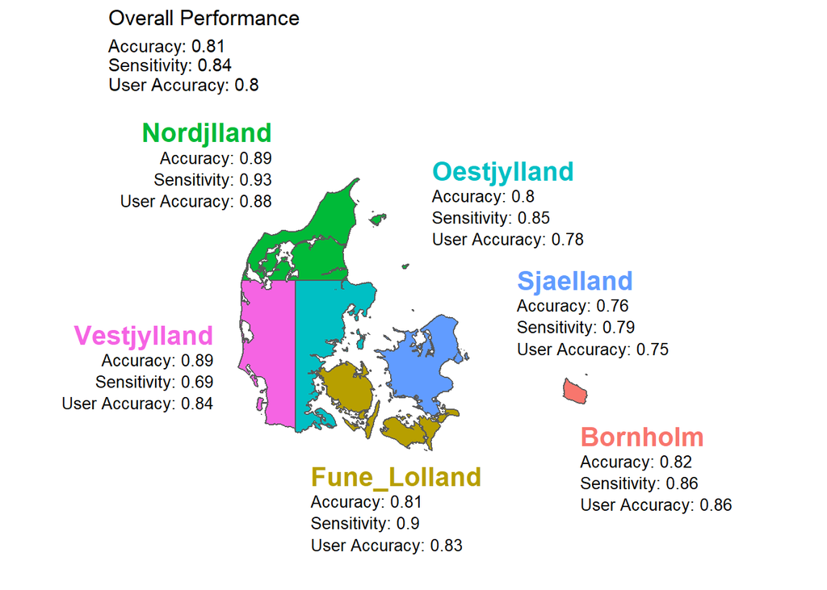

Performance table based on the independent validation data:

| Measure | Overall | Bornholm | Fune_Lolland | Nordjlland | Oestjylland | Sjaelland | Vestjylland |
| --- | --- | --- | --- | --- | --- | --- | --- |
| Accuracy | 0.81 | 0.82 | 0.81 | 0.89 | 0.80 | 0.76 | 0.89 |
| Error | 0.19 | 0.18 | 0.19 | 0.11 | 0.20 | 0.24 | 0.11 |
| Sensitivity (True Positive Rate) | 0.84 | 0.86 | 0.90 | 0.93 | 0.85 | 0.79 | 0.69 |
| Specificity (True Negative Rate) | 0.79 | 0.75 | 0.63 | 0.86 | 0.75 | 0.72 | 0.95 |
| Fall-out (False Positive Rate) | 0.21 | 0.25 | 0.37 | 0.14 | 0.25 | 0.28 | 0.05 |
| Positive predictive value (User Accuracy) | 0.80 | 0.86 | 0.83 | 0.88 | 0.78 | 0.75 | 0.84 |

Performance table based on the dependent training data:

| Measure | Overall | Bornholm | Fune_Lolland | Nordjlland | Oestjylland | Sjaelland | Vestjylland |
| --- | --- | --- | --- | --- | --- | --- | --- |
| Accuracy | 1 | 1 | 1 | 1 | 1 | 0.99 | 0.99 |
| Error | 0 | 0 | 0 | 0 | 0 | 0.01 | 0.01 |
| Sensitivity (True Positive Rate) | 1 | 1 | 1 | 1 | 1 | 0.99 | 0.98 |
| Specificity (True Negative Rate) | 1 | 1 | 1 | 1 | 1 | 0.99 | 1.00 |
| Fall-out (False Positive Rate) | 0 | 0 | 0 | 0 | 0 | 0.01 | 0.00 |
| Positive predictive value (User Accuracy) | 1 | 1 | 1 | 1 | 1 | 0.99 | 1.00 |

### Perfromance in Derek’s regions:

Performance map based on the independent validation data:

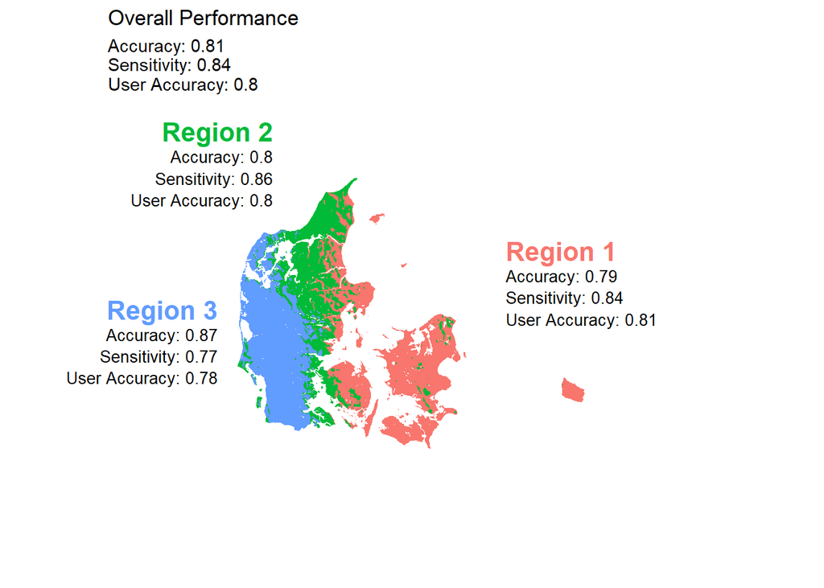

Performance table based on the independent validation data:

| Measure | Overall | Region 1 | Region 2 | Region 3 |
| --- | --- | --- | --- | --- |
| Accuracy | 0.81 | 0.79 | 0.80 | 0.87 |
| Error | 0.19 | 0.21 | 0.20 | 0.13 |
| Sensitivity (True Positive Rate) | 0.84 | 0.84 | 0.86 | 0.77 |
| Specificity (True Negative Rate) | 0.79 | 0.70 | 0.72 | 0.92 |
| Fall-out (False Positive Rate) | 0.21 | 0.30 | 0.28 | 0.08 |
| Positive predictive value (User Accuracy) | 0.80 | 0.81 | 0.80 | 0.78 |

Performance table based on the dependent training data:

| Measure | Overall | Region 1 | Region 2 | Region 3 |
| --- | --- | --- | --- | --- |
| Accuracy | 1 | 1.00 | 1 | 1.00 |
| Error | 0 | 0.00 | 0 | 0.00 |
| Sensitivity (True Positive Rate) | 1 | 1.00 | 1 | 0.99 |
| Specificity (True Negative Rate) | 1 | 0.99 | 1 | 1.00 |
| Fall-out (False Positive Rate) | 0 | 0.01 | 0 | 0.00 |
| Positive predictive value (User Accuracy) | 1 | 1.00 | 1 | 1.00 |

### Performance by forest type (boradleaf vs. coniferous)

Performance table based on the independent validation data:

[output not shown]

Performance table based on the dependent training data:

[output not shown]